# ggplot2 live coding script

### Violin plot

Variation on box plot in which density is shown along the sides of the “violin”.

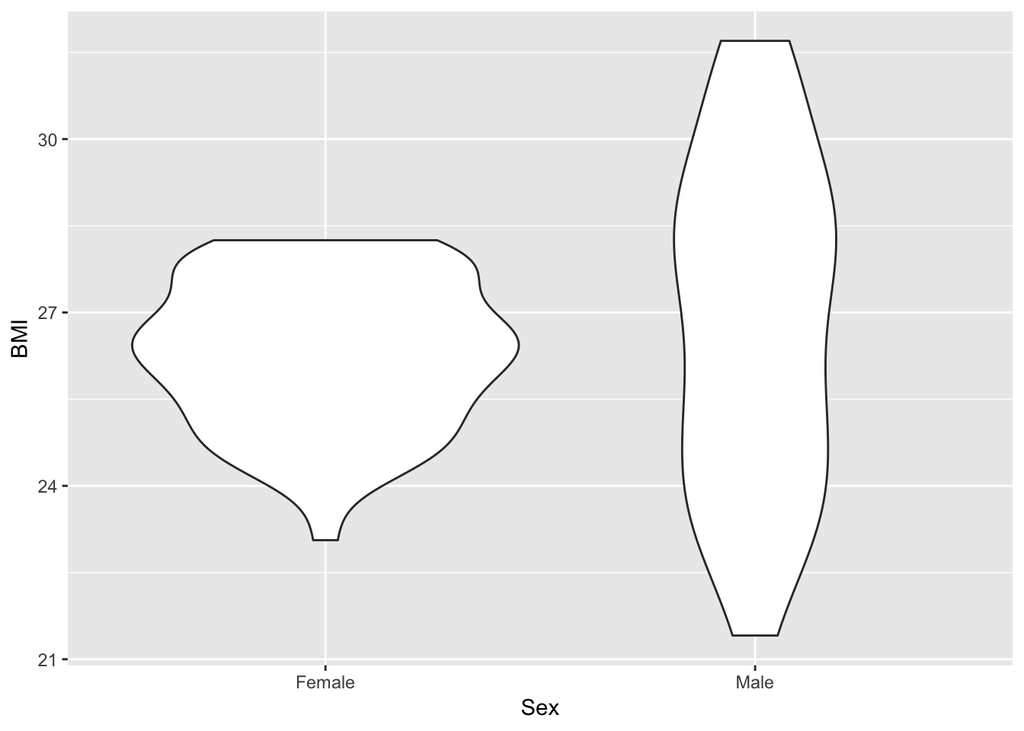

```r
ggplot(data = patients, mapping = aes(x = Sex, y = BMI)) +
  geom_violin()
```

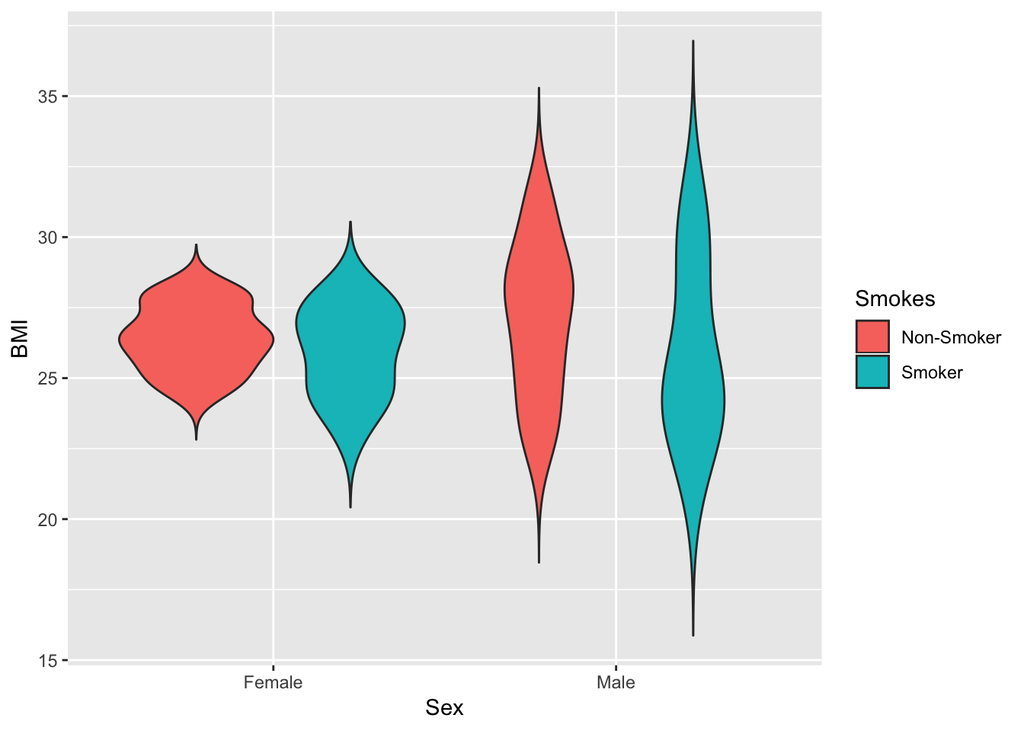

```r
ggplot(data = patients, mapping = aes(x = Sex, y = BMI, fill = Smokes)) +
  geom_violin(trim = FALSE)
```

### Density plot

Deliberately not covering this here as it is required for a couple of the exercises and we want you to work it out for yourself using the help pages and what you’ve learned so far about the common grammar for all ggplots.

## Exercises part I - geoms and aesthetics

See separate R markdown document.